# ARIMA

Auto ARIMA

```r
fit <- auto.arima(ts_data)
summary(fit)
```

```
## Series: ts_data
## ARIMA(4,1,1)
##
## Coefficients:
##          ar1      ar2     ar3     ar4      ma1
##       0.4742  -0.0068  0.0940  0.0671  -0.9756
## s.e.  0.0201   0.0215  0.0215  0.0199   0.0055
##
## sigma^2 = 1.029e+15:  log likelihood = -50103.16
## AIC=100218.3   AICc=100218.3   BIC=100253.7
##
## Training set error measures:
##                    ME     RMSE      MAE       MPE     MAPE      MASE
## Training set 600342.1 32048759 21234112 -3077.273 3097.548 0.9032762
##                      ACF1
## Training set -0.001202735
```

Auto ARIMA has recommended an ARIMA(4,1,1) model, which differs from the previously determined ARIMA(3,1,2) model that was considered the best option. The discrepancy can likely be attributed to the presence of outliers in the data, primarily resulting from the impact of COVID. Auto ARIMA is equipped to handle outliers more effectively, and this might explain the variation in model selection.

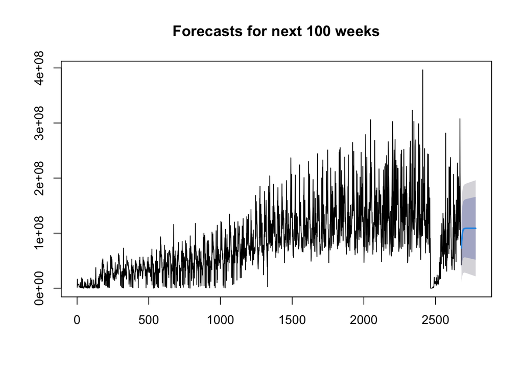

```r
# Assuming you've loaded the necessary libraries and your time series data is in 'ts_data'

# Fit the ARIMA(3,1,2) model
library(forecast)
model <- arima(ts_data, order=c(3,1,2))

# Forecast for the next 4 periods
forecasted <- forecast(model, h=100)

# Plot the forecast with confidence intervals
plot(forecasted , main = "Forecasts for next 100 weeks")
```

Over the forthcoming 100 weeks, the box office is projected to experience a modest performance. This anticipated trend aligns with the expected release of fewer blockbuster movies during this timeframe. However, it’s crucial to note the wide confidence interval in the forecast, which suggests potential variability in the box office numbers. This could indicate the possibility of occasional surprise hits making their mark amidst the general trend, thereby offering moments of heightened success in an otherwise moderate performance period.

Benchmarks

Naive Methods:

```r
# Compute forecasted values

arima_model <- arima(ts_data, order=c(3,1,2))
yhat_arima <- fitted(arima_model)
yhat_naive <- c(NA, ts_data[-length(ts_data)])

mean((yhat_arima - ts_data)^2)
```

```
## [1] 1.026754e+15
```

```r
# Compute forecasted values

arima_model <- arima(ts_data, order=c(3,1,2))
yhat_naive <- c(NA, ts_data[-length(ts_data)])

mean((yhat_naive - ts_data)^2 , na.rm = TRUE)
```

```
## [1] 1.353205e+15
```

Naive is a worse model.

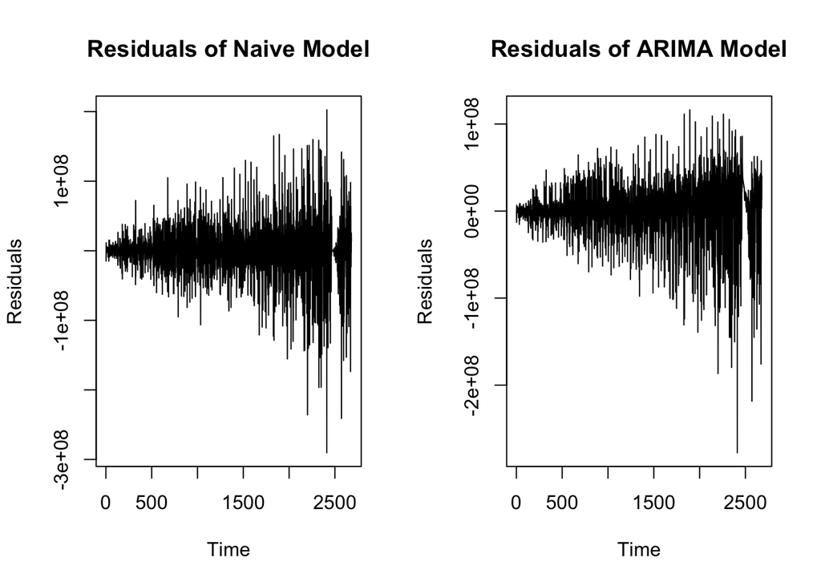

```r
# Compute residuals for both models
residuals_naive <- yhat_naive - ts_data
residuals_arima <- yhat_arima - ts_data

# Set up subplot layout
par(mfrow=c(1,2))

# Plot residuals for naive model
plot(residuals_naive, main="Residuals of Naive Model", type="l", ylab="Residuals", xlab="Time")

# Plot residuals for ARIMA model
plot(residuals_arima, main="Residuals of ARIMA Model", type="l", ylab="Residuals", xlab="Time")
```

```r
# Reset plot layout
par(mfrow=c(1,1))
```

From the visual representations of the residuals for both the Naive and ARIMA models, we can observe distinct differences in their performance. The residuals from the Naive model showcase more pronounced fluctuations with a broader spread, while the ARIMA model appears to have a relatively tighter and more controlled residual distribution. The consistency in the ARIMA model’s residuals suggests that this model is capturing the underlying patterns in the data more effectively than the Naive model. This observation aligns with the quantitative metric, where the Mean Squared Error (MSE) for the Naive model is higher than that of the ARIMA model. A lower MSE indicates that the ARIMA model’s predictions are closer to the actual values, thus demonstrating its superior forecasting accuracy in this context compared to the simpler Naive model.